# Procrustes distance or area of landmark variation?

Thomas Guillerme

2018-12-03

What is the difference between the Procrustes distance as used in `geomorph` or the cumulative landmark variation (or area difference between landmark displacement)? Both are different methods do differentiate specimens from another specimen (usually the mean shape) and are based on their landmark configuration. However, they differ in terms of the obtained results:

# Definitions:

## Procrustes distance

The Procrustes distance (Kendall 1984, *Bulletin of the London Mathematical Society* 16: 81–121) is the Euclidean distance in the Kendall shape space (i.e. the Euclidean distance between all the landmark coordinates between two specimens):

$D_{F}(x,y) = \sqrt{\sum_{i}^{n}(x_{i}-y_{i})^2}$

Where *x* and *y* are two specimens with *n* landmarks each.

## Cumulative landmark variation (or area difference)

The cumulative landmark variation (or area difference) is defined as follows:

$D_{area}(x,y) = \int_{0}^{n-1} (f_{x} - f_{y})d(x,y)$

Where $f_{x}$ and $f_{y}$ are ranked functions (i.e. $f_{0} \geq f_{1} \geq f_{2} ...$) for the landmarks in the partition and all the landmarks respectively.

## Difference between both

```r
## Loading the packages
if(!require(devtools)) install.packages("devtools")
if(!require(geomorph)) install.packages("geomorph")
if(!require(landvR)) install_github("TGuillerme/landvR")
```

We can compare both metrics on the `geomorph` `plethodon` dataset:

```r
## Loading the plethodon dataset
data(plethodon)

## Performing the Procrustes superimposition
procrustes_super <- geomorph::gpagen(plethodon$land, print.progress = FALSE)

## The mean specimen shape
mean_shape <- landvR::select.procrustes(procrustes_super, selector = mean)

## Transforming the gpagen coordinates into a list
procrustes <- landvR::array.to(procrustes_super$coords, "list")
```

We can simply calculate the Procrustes distance as follows:

```r
## The Procrustes distances
proc.distance <- function(x, mean) {
    return(dist(rbind(as.vector(x), as.vector(mean)), "euclidean"))
}
proc_distances <- unlist(lapply(procrustes, proc.distance, mean = mean_shape[[1]]))
```

We can then calculate the area differences as follows:

```r
## Getting the polar coordinates from the mean shape for each specimen
spherical_diff <- coordinates.difference(procrustes, mean_shape[[1]],
                                     type = "spherical", angle = "degree")

## Getting the area differences
area_differences <- unlist(lapply(spherical_diff, landvR::coordinates.area, what = "radius"))
```

And we can then visually compare both:

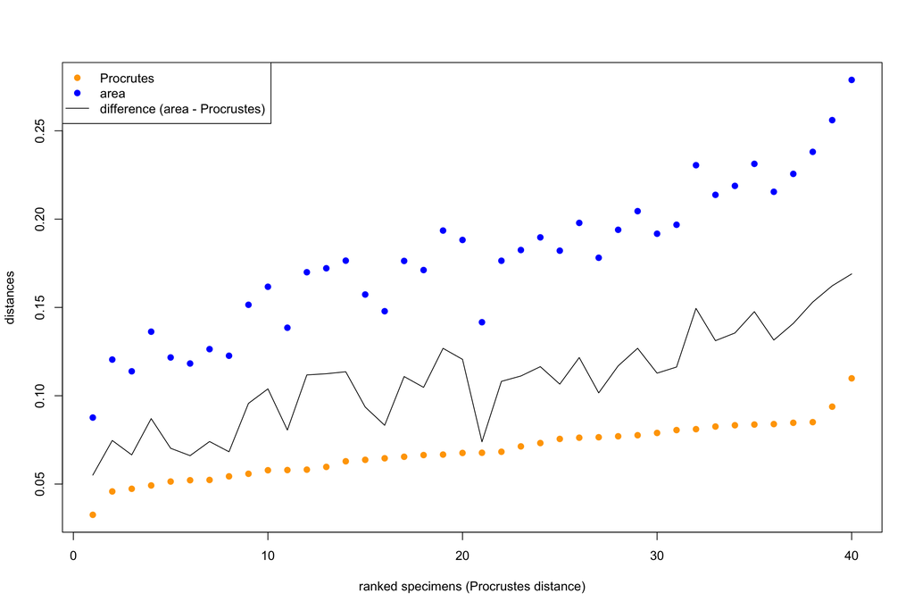

```r
## Ranking both set by specimens' Procrustes distances
rank <- match(sort(proc_distances), proc_distances)

## Plotting the different distances and the difference between them
plot(proc_distances[rank], pch = 19, ylim = range(c(proc_distances, area_differences)),
    col = "orange", xlab = "ranked specimens (Procrustes distance)", ylab = "distances")
points(area_differences[rank], pch = 19, col = "blue")
lines(area_differences[rank]-proc_distances[rank])
legend("topleft", legend = c("Procrutes", "area", "difference (area - Procrustes)"),
       pch = c(19, 19, NA), lty = c(0, 0, 1) , col = c("orange", "blue", "black"))
```

Here we can see that both distances do not scale one to one although the seem to display a similar trend (i.e. the specimen with the smaller/bigger Procrustes distance are the ones with the smaller/bigger area differences).

## Advantages of the area difference

Although the Procrustes distance has been (righlty) shown to be perfectly fine for differentiating specimens based on their configuration in the Kendall shape space (which reflects the differences between landmarks), using the area difference allows some modifications that can impact the study based on the question at hand:

- $f_{x}$ and $f_{y}$ can be defined by any function for differentiating two landmarks. This can be the distance between two landmarks (Euclidean or otherwise) or any other metric (angle, ratio, etc.).
- $D_{area}(x,y)$ is effectively a ranked distribution and allows more fine scale comparison between two sets of landmarks (i.e. differentiating specimens based on the ranked distribution of their landmark displacement).
- $D_{area}(x,y)$ reflects directly the difference in terms of distribution of landmark variation whereas $D_{F}$ reflects the difference in *specimens* (*cf.* landmarks) in the Kendall shape space (though based on the same landmark variation.)

## Visualising some more differences

Comparing how the different distances react to different points (e.g. mean or median) and with different optimisations (landmark displacement length or landmark displacement angle):

```r
## Getting the area differences from the mean based on the angle
angle_area_differences <- unlist(lapply(spherical_diff, landvR::coordinates.area, what = "azimuth"))

## The median shape
median_shape <- landvR::select.procrustes(procrustes_super, selector = median)

## The Procrustes distances to the median
median_proc_distances <- unlist(lapply(procrustes, proc.distance, mean = median_shape[[1]]))

## Getting the polar coordinates from the mean shape for each specimen
median_spherical_diff <- coordinates.difference(procrustes, median_shape[[1]],
                                     type = "spherical", angle = "degree")

## Getting the area differences from the median
median_area_differences <- unlist(lapply(median_spherical_diff, landvR::coordinates.area,
                                         what = "radius"))

## Getting the area differences from the median based on the angle
median_angle_area_differences <- unlist(lapply(median_spherical_diff, landvR::coordinates.area,
                                               what = "azimuth"))
```

For simplifying the plot, we will scale all the distances between 0 and 1:

```r
## Making all the distances into a list
distance_list <- list(proc_distances, median_proc_distances,
                      area_differences, median_area_differences,
                      angle_area_differences, median_angle_area_differences)
## Scaling the distances
distance_list <- lapply(distance_list, function(x) x/max(x))
```

And we can now plot all the different distances, again based on the ranked Procrustes distances from the mean:

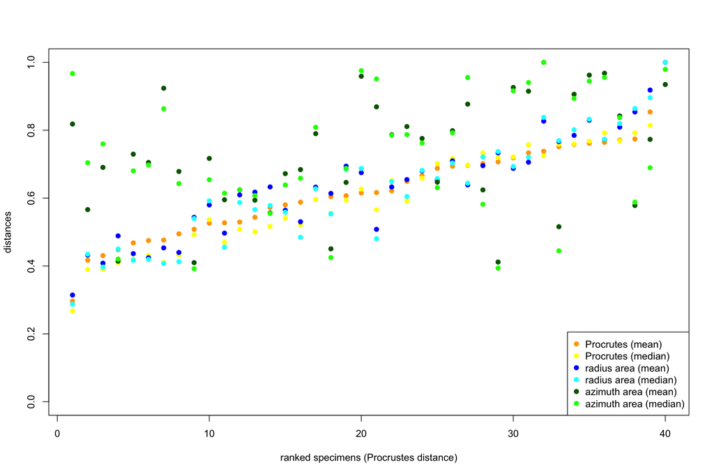

```r
## The list of colours
cols <- c("orange", "yellow", "blue", "cyan", "darkgreen", "green")

## The empty plot
plot(NULL, xlim = c(1,40), ylim = c(0,1), xlab = "ranked specimens (Procrustes distance)",
     ylab = "distances")

## The ranked/scaled distances
for(one_dist in 1:length(distance_list)) {
    points(distance_list[[one_dist]][rank], pch = 19, col = cols[one_dist])
}

## The legend
legend("bottomright", pch = 19, col = cols, legend = c("Procrutes (mean)", "Procrutes (median)",
                                                    "radius area (mean)", "radius area (median)",
                                                    "azimuth area (mean)", "azimuth area (median)"))
```